# Lab08NotTeamOne

David Orozco, Ryan Tate, Arie del Valle, Anderson Mun, Ethan Schacht

March 6, 2019

### Team Section

#### Question

- Overal Question: What are the factors that affect the avergage price of avocados, and how can we understand these factors to generate more sales? This is important becuase understanding the what factors affect average price can help avacado sellers to maximize profit. It also allows for avacado buyers to save money. Note: Who doesn’t love avocadoes?!

#### Data

Volume effect on Price:

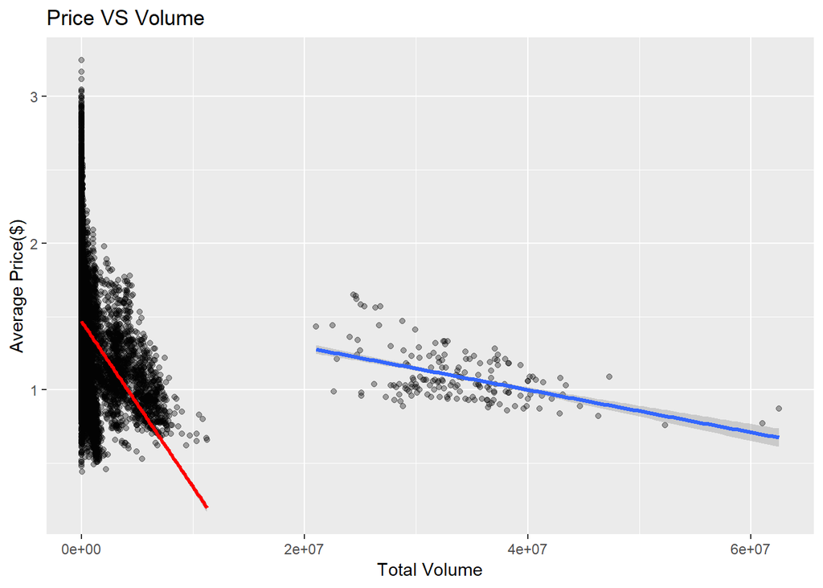

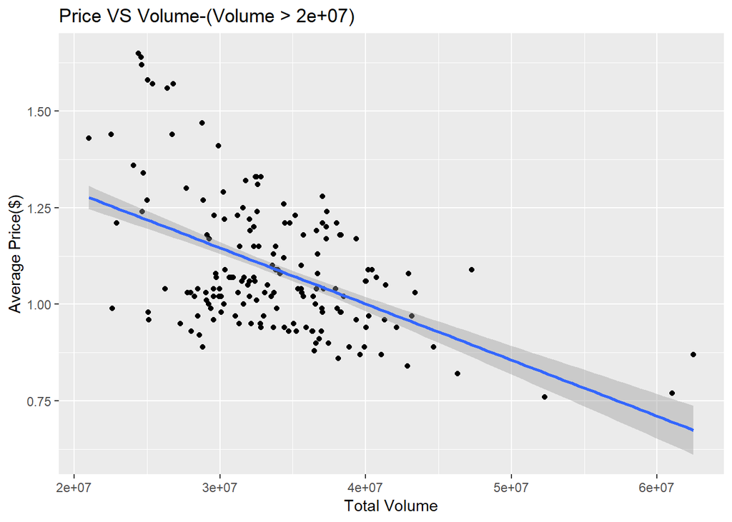

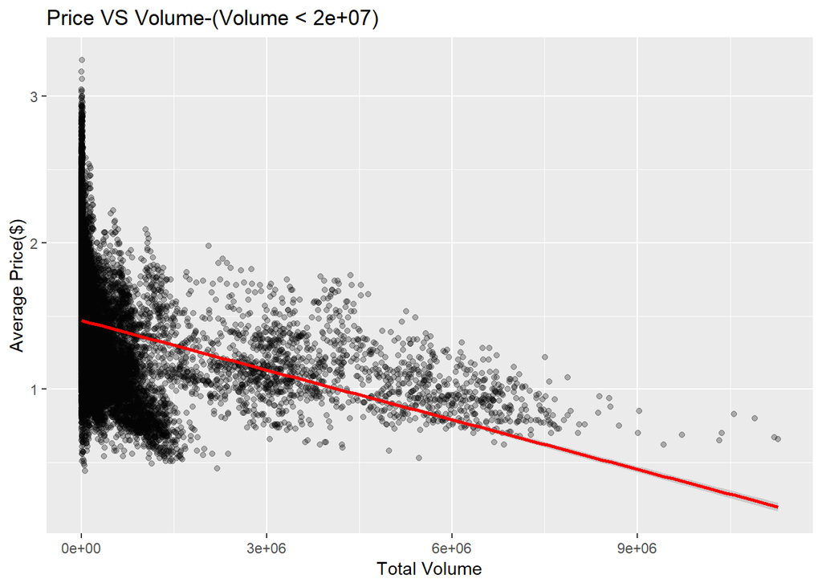

```
## [1] -0.5099603
```

```
## [1] -0.3419494
```

- There is a negative coorelation between the average price of avocadoes and the total volume of avocadoes present. This makes sense because the more avocadoes you have, the quiker you need to sell them. Thus, it would make sense to lower the prices. This correlation becomes stronger with volumes greater than 2e+07. Red line coorelation is -.34, while the blue line is -.50. This leads us to believe that with excessive amounts of avocadoes,it would be more profitable to decrease the prices than letting avocadoes go to waste.
- Note: The darker the point, the more points overlap there.

Regional effect on Price:

```
## # A tibble: 54 x 2
##   region         mean
##   <fct>         <dbl>
## 1 Houston        1.05
## 2 DallasFtWorth  1.09
## 3 SouthCentral   1.10
## # ... with 51 more rows
```

- The tibble above shows the regions in which the mean avereage avocadoes price throughout the year is the lowest. Houston, Dallas, and SouthCentral regions have the losest avocado prices. Note: Hartford/Springfield have the highest avocado prices.

Monthly effect on Price:

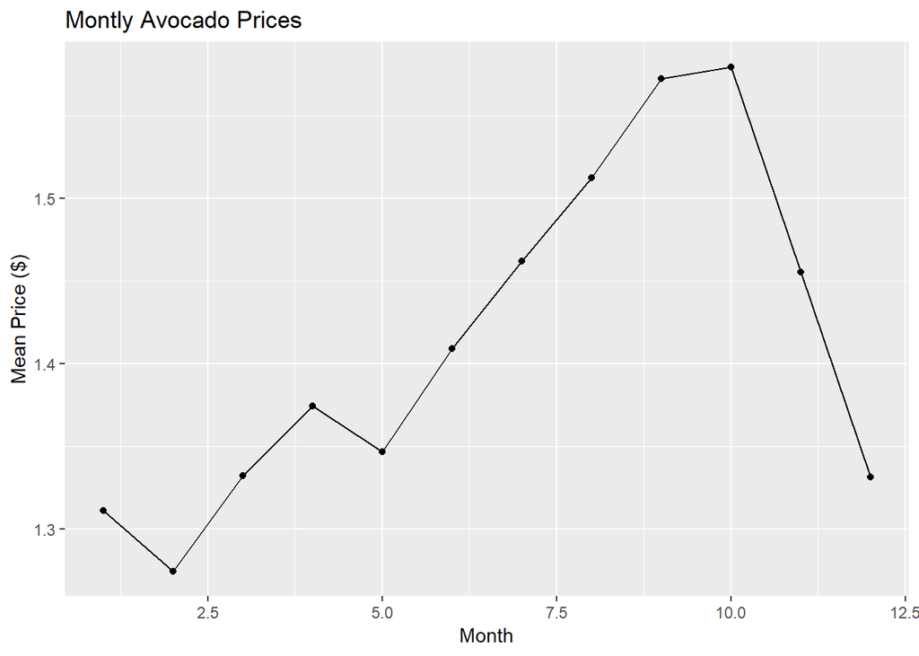

- The mean monthly avereage price of avocadoes steadily increases throughout the year and then pluments around the colder months (approx November). This coorelates well with avocado season which ,depending on the type of avocado, ranges from August-November.

Annual effect on prices:

```
## # A tibble: 4 x 2
##    Year  mean
##   <int> <dbl>
## 1  2018  1.35
## 2  2017  1.52
## 3  2016  1.34
## 4  2015  1.38
```

- There does not seem to be an annual increase in mean avocado prices. Although there is a price spike in 2017. This coincides with the 2017 drought, the worst drought in 17 years. This could explain the possible price spike. Note: Where’s My Water??

Organic Vs. Conventional

```
## # A tibble: 2 x 2
##   type          mean
##   <fct>        <dbl>
## 1 organic       1.65
## 2 conventional  1.16
```

- The tibble above shows the average price of avocaodes based on their type (Conventional or Organic). Organic avocadoes are a whopping 50 cents more on average! Note: With 50 U.S cents, you can buy 2 glasses of beer in Vietnam!

#### Conclusion/Recommendations

- Our objective was to manipulate data about avocado sales, in order to identify factors that will boost revenue for retailers. Together we created a general plot that compares the total volume of sales to the avergae price. We discovered that there was a separation in the plot when total volume reached 2e+07. The total volume that was less than 2e+07 displayed a weak negative correlation. While the total volume greater than 2e+07 showed a strong negative correlation. Individually we compared several factors that may affect the average price. From these plots, we noticed that region, type, and year affect average price. The best corse of action to maximize profit is to keep avocado prices low while in season, and upsale on pairings such as tortilla chips and artisan bread. Total number of sales are highest when they are in season and cheaper prices will attract the consumers, while upselling on tortilla chips and bread will add on to their total cost, therefore increasing revenue.

#### Domain Expert

- The domain expert is an exec at big avocado trying to maximize profits by understanding different factors that effect avocado prices.

### Individual Section

#### David’s Section

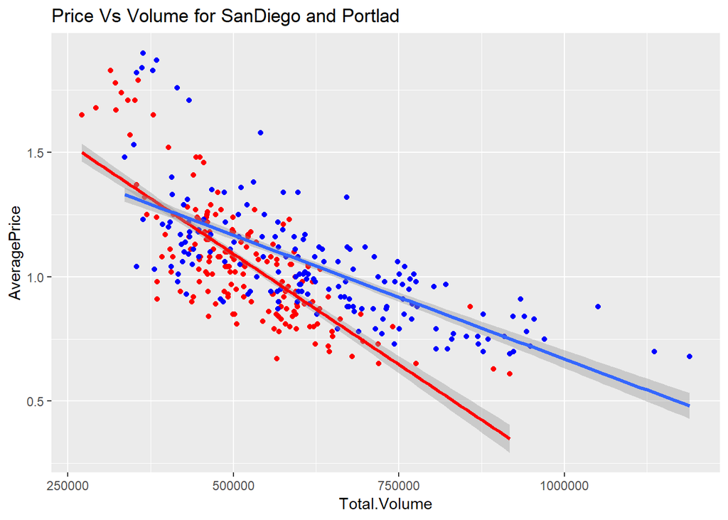

```
## [1] -0.7528281
```

```
## [1] -0.7081038
```

- The graph above shows a strong negative correlation between average price and the total volume of avocadoes. This agrees with concepts of supply and demand. The red points are for the region of SanDiego and the blue points are for the region of Portland.The coorelation for each region is -0.7528281 and -0.7081038 respectively.
- There are several verbs I used to tidy the avocado data. First, I used seperate and parse_interger to turn the date into usable columns of day,month, and year. I also used gather to combine the PLU codes for the avocadoes into one variable. Finally, I used filter to graph average price against the total volume in respect to a region, specifically SanDiego and Portland.

#### Arie’s Section

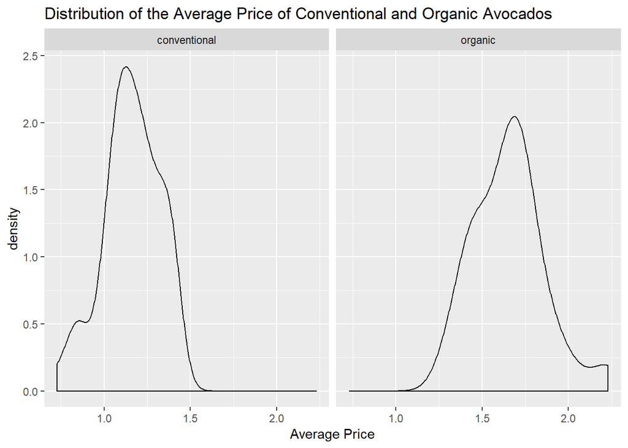

- Findings: This graph shows that the there is a higher distribution of conventional avocados than organic avocados. From this graph it shows that the average price amongst all regions is around $1.10 for conventional and $1.60 for organic.
- I used select to use the variables I wanted to work with. I grouped by region and type. I then took the average of each region with summarise. I created a ggplot with the new data I created. I wanted to compare the distribution of average price between conventional and organic avocados. So I used geom_density and faceted with type.

#### Anderson’s Section

```
## # A tibble: 5 x 5
##   Region     AverageBag SmallBags LargeBags XLargeBags
##   <chr>           <dbl>     <dbl>     <dbl>      <dbl>
## 1 Albany          7930.     6648.     1153.       128.
## 2 Boston         63596.    58907.     4438.       251.
## 3 California    729829.   677804.    36426.     15599.
## 4 Denver        174429.    55514.   118760.       155.
## 5 Houston       148565.    96228.    51372.       965.
```

- I have created a tibble that shows the average amount of bags of avacados among five seperate regions varying from Albany to Houston. In the tibble you can see the average values of small, large and extra large bags for each region.
- To generate my findings for the tibble I used a group by function and a summarise function to find the mean of the amount of any particular bag size for each region.

#### Ryan’s Section

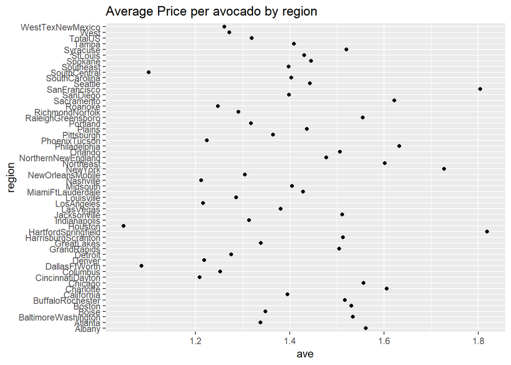

- I tiddied my data by putting it into a tibble with as_tibble and read_csv. I then transformed my data with a group by and summarize to group the average price by region. Then I used an arrange with desc order to find the best region for avocado buying, which is Houston, or H-town as the locals call it.
- I found that Houston was the region with the cheapest average avocado price, followed closely by Dallas, then the South Central region. The regions with the highest average price per avocado were Hartford Springfiled, San Francisco, and New York.

#### Ethan’s Section

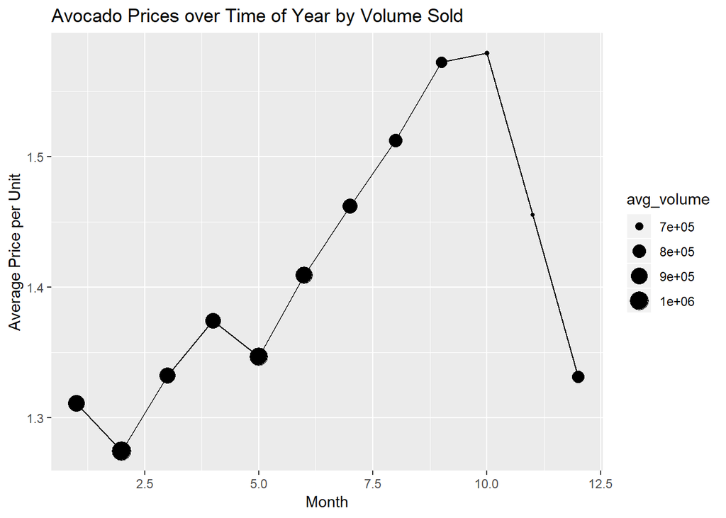

- Findings: I asked the question of how the price of avocados changes throughout the year. I tidied the data by separating date into year, month, and day and transformed the data by grouping into month and summarising average price and volume stats. This graph displays the time of year (month) against the average price of avocadoes per unit, also illustrating the volume of avocados sold at every data point by size. The average price of avocados steadily increases throughout the year until October, when the prices begin to plummet. We can also see that the volume sold generally decreases as the price increases, which makes sense due to supply and demand and also suggests that avocados are freshest / most in season around January through May.

#### Who did what?

Note: The Vietnamese Currency (VND), is called the dong! :)

- Arie- Helped come up with question and writing the conclusion
- Anderson- good team attitude
- Ethan- ind section and findings, recommendations
- David- Individual section, started GitHub Repository, Managed GitKraken merge conflicts, added team data comparisons for Average price against the following variables: Volume,Region,Type,and Year.
- Ryan- Did his individual section and worked on data description and domain expert.